# lab5.1

Nikitina Natalia

4 декабря 2017 г

```r
#Дисперсионный анализ

#Загрузим данные (требуется установить Рабочую папку с помощью setwd) или указать полный путь
data = read.csv("https://raw.githubusercontent.com/SergeyMirvoda/MD-DA-2017/master/data/diet.csv",row.names=1)
summary(data)
```

```
##      gender            Age            Height        pre.weight
##  Min.   :0.0000   Min.   :16.00   Min.   :141.0   Min.   : 58.00
##  1st Qu.:0.0000   1st Qu.:32.25   1st Qu.:164.2   1st Qu.: 66.00
##  Median :0.0000   Median :39.00   Median :169.5   Median : 72.00
##  Mean   :0.4342   Mean   :39.15   Mean   :170.8   Mean   : 72.53
##  3rd Qu.:1.0000   3rd Qu.:46.75   3rd Qu.:174.8   3rd Qu.: 78.00
##  Max.   :1.0000   Max.   :60.00   Max.   :201.0   Max.   :103.00
##  NA's   :2
##       Diet        weight6weeks
##  Min.   :1.000   Min.   : 53.00
##  1st Qu.:1.000   1st Qu.: 61.85
##  Median :2.000   Median : 68.95
##  Mean   :2.038   Mean   : 68.68
##  3rd Qu.:3.000   3rd Qu.: 73.83
##  Max.   :3.000   Max.   :103.00
##
```

```r
#Ознакомимся со структурой и переименуем колонки, как нам удобно
#https://www.sheffield.ac.uk/polopoly_fs/1.547015!/file/Diet_data_description.docx
#https://www.sheffield.ac.uk/mash/data
colnames(data) <- c("gender", "age", "height", "initial.weight",
                    "diet.type", "final.weight")
data$diet.type <- factor(c("A", "B", "C")[data$diet.type])
#Добавим новую колонку - Похудение
data$weight.loss = data$initial.weight - data$final.weight

#Проведем t-тест, чтобы узнать, был ли вес потерян
t.test(data$weight.loss, alternative = "l")
```

```
##
##  One Sample t-test
##
## data:  data$weight.loss
## t = 13.309, df = 77, p-value = 1
## alternative hypothesis: true mean is less than 0
## 95 percent confidence interval:
##      -Inf 4.325854
## sample estimates:
## mean of x
##  3.844872
```

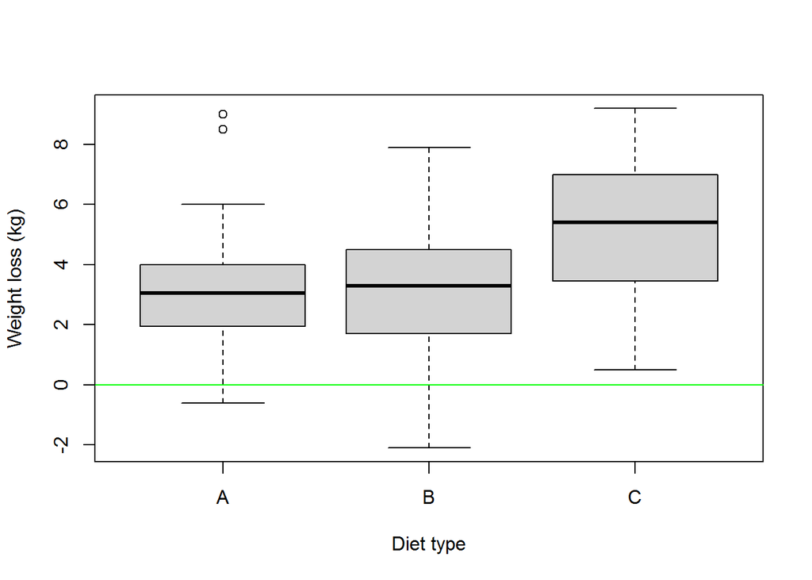

```r
#Проанализиуем есть ли различия по типам диет
boxplot(weight.loss~diet.type,data=data,col="light gray",
        ylab = "Weight loss (kg)", xlab = "Diet type")
abline(h=0,col="green")
```

```r
#проверим сбалансированные ли данные
table(data$diet.type)
```

```
##
##  A  B  C
## 24 27 27
```

```r
#График групповых средних
library(gplots) #библиотека устанавлевается с помощью install.packages
plotmeans(weight.loss ~ diet.type, data=data)
aggregate(data$weight.loss, by = list(data$diet.type), FUN=sd)
```

```
##   Group.1        x
## 1       A 2.240148
## 2       B 2.523367
## 3       C 2.395568
```

```r
#Для подгонки ANOVA модели используем функцию aov, частный случай линейной модели lm
#тест на межгрупповые различия
fit <- aov(weight.loss ~ diet.type, data=data)
summary(fit)
```

```
##             Df Sum Sq Mean Sq F value  Pr(>F)
## diet.type    2   71.1   35.55   6.197 0.00323 **
## Residuals   75  430.2    5.74
## ---
## Signif. codes:  0 '***' 0.001 '**' 0.01 '*' 0.05 '.' 0.1 ' ' 1
```

```r
#попарные различия между средними значениями для всех групп
TukeyHSD(fit)
```

```
##   Tukey multiple comparisons of means
##     95% family-wise confidence level
##
## Fit: aov(formula = weight.loss ~ diet.type, data = data)
##
## $diet.type
##           diff        lwr      upr     p adj
## B-A -0.2740741 -1.8806155 1.332467 0.9124737
## C-A  1.8481481  0.2416067 3.454690 0.0201413
## C-B  2.1222222  0.5636481 3.680796 0.0047819
```

```r
#Tukey honest significant differences test)
library(multcomp)
```

[figure not shown]

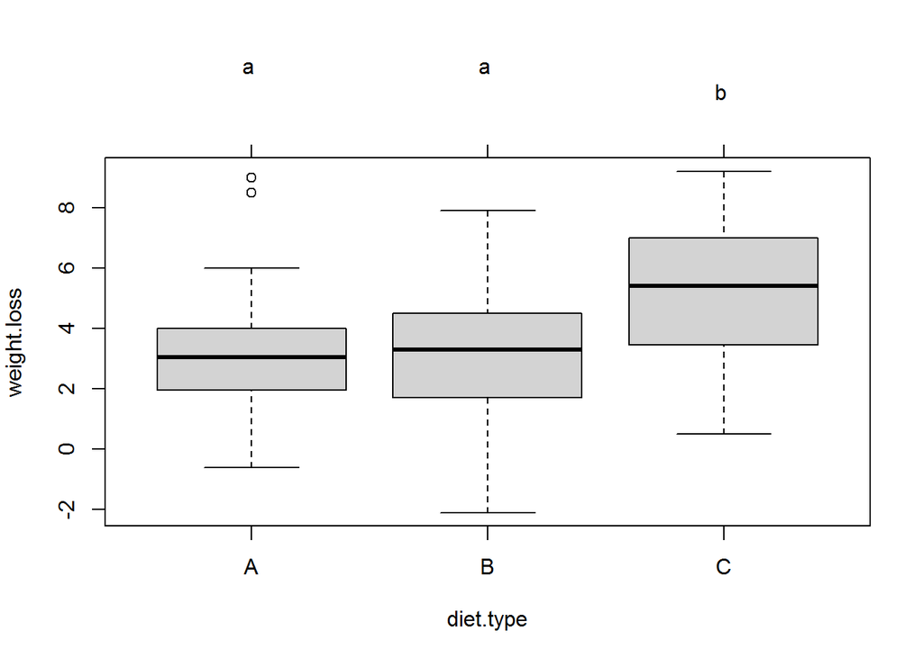

```r
par(mar=c(5,4,6,2))
tuk <- glht(fit, linfct=mcp(diet.type="Tukey"))
plot(cld(tuk, level=.05),col="lightgrey")
```

```r
#Задание
#Добавить проверку на выборы и избавиться от них
#повторно проверсти все тесты и сравнить результаты с выбросами и без
#Открыть документ https://www.sheffield.ac.uk/polopoly_fs/1.547015!/file/Diet_data_description.docx
#и попытаться выполнить задания из него
```

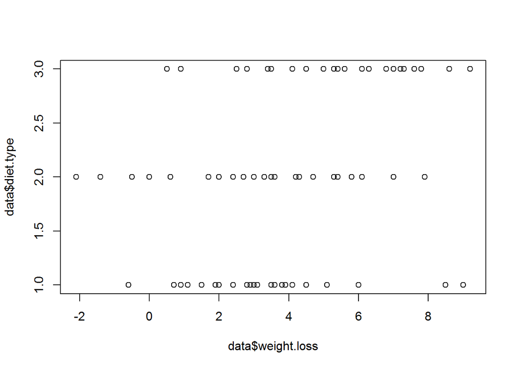

```r
#Определение выбросов
plot(data$weight.loss,data$diet.type)
```

```r
data.noout<-data[data$weight.loss<=8,]
```

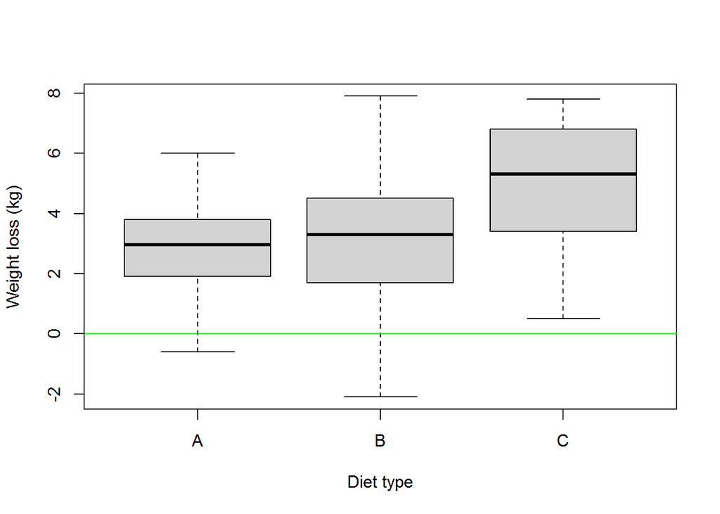

```r
#Повторное проведение тестов без выбросов

#Проанализиуем есть ли различия по типам диет
boxplot(weight.loss~diet.type,data=data.noout,col="light gray",
        ylab = "Weight loss (kg)", xlab = "Diet type")
abline(h=0,col="green")
```

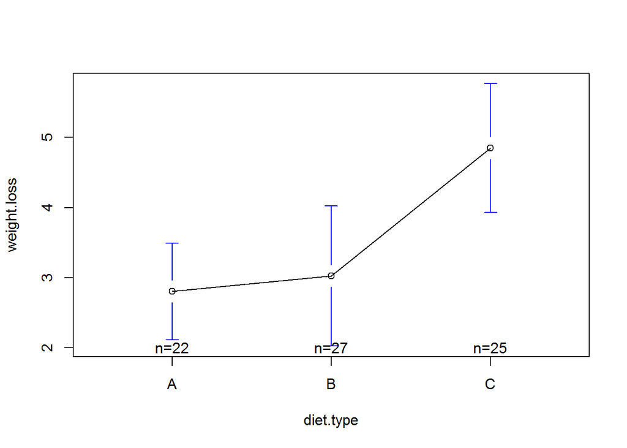

```r
#График групповых средних
plotmeans(weight.loss ~ diet.type, data=data.noout)
```

```r
aggregate(data.noout$weight.loss, by = list(data.noout$diet.type), FUN=sd)
```

```
##   Group.1        x
## 1       A 1.550569
## 2       B 2.523367
## 3       C 2.223196
```

```r
#Для подгонки ANOVA модели используем функцию aov, частный случай линейной модели lm
#тест на межгрупповые различия
fit.noout <- aov(weight.loss ~ diet.type, data=data.noout)
summary(fit.noout)
```

```
##             Df Sum Sq Mean Sq F value  Pr(>F)
## diet.type    2   61.7  30.856   6.546 0.00246 **
## Residuals   71  334.7   4.714
## ---
## Signif. codes:  0 '***' 0.001 '**' 0.01 '*' 0.05 '.' 0.1 ' ' 1
```

```r
#попарные различия между средними значениями для всех групп
TukeyHSD(fit.noout)
```

```
##   Tukey multiple comparisons of means
##     95% family-wise confidence level
##
## Fit: aov(formula = weight.loss ~ diet.type, data = data.noout)
##
## $diet.type
##          diff        lwr      upr     p adj
## B-A 0.2213805 -1.2713237 1.714085 0.9329494
## C-A 2.0434545  0.5241792 3.562730 0.0054330
## C-B 1.8220741  0.3795645 3.264584 0.0096111
```

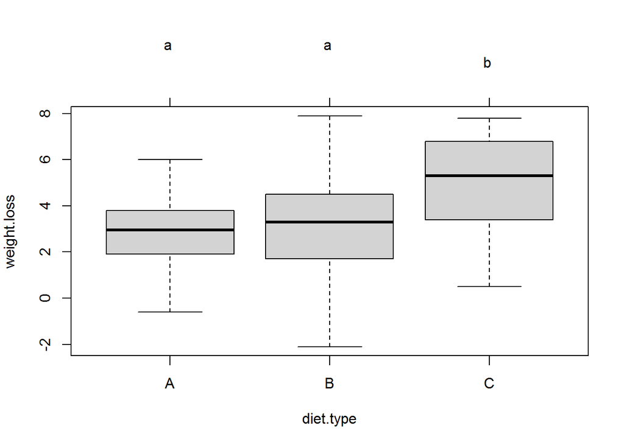

```r
#Tukey honest significant differences test)
par(mar=c(5,4,6,2))
tuk.noout <- glht(fit.noout, linfct=mcp(diet.type="Tukey"))
plot(cld(tuk.noout, level=.05),col="lightgrey")
```

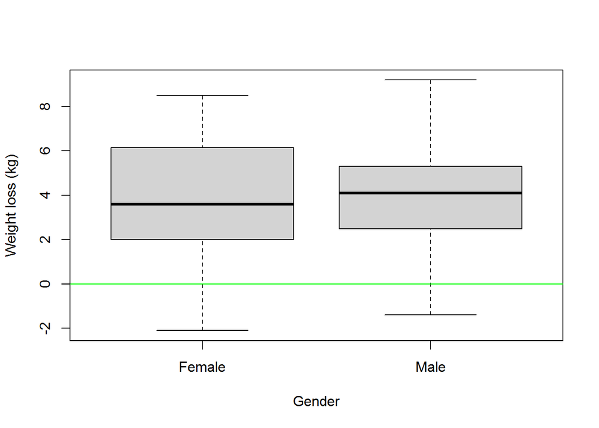

```r
#Зависимость потери веса от пола

#Определение выбросов
data.noout.2<-data[!is.na(data$gender),]
data.noout.2$gender <- factor(c("Female","Male")[as.ordered(data.noout.2$gender)])

#Проанализиуем, есть ли различия по полу
boxplot(weight.loss~gender,data=data.noout.2,col="light gray",
        ylab = "Weight loss (kg)", xlab = "Gender")
abline(h=0,col="green")
```

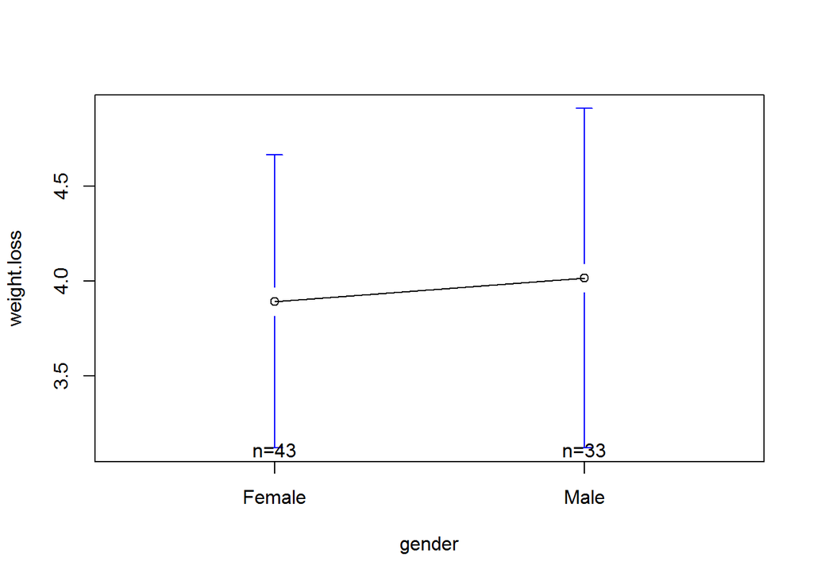

```r
#График групповых средних
plotmeans(weight.loss ~ gender, data=data.noout.2)
```

```r
aggregate(data.noout.2$weight.loss, by = list(data.noout.2$gender), FUN=sd)
```

```
##   Group.1        x
## 1  Female 2.515892
## 2    Male 2.529837
```

```r
#Для подгонки ANOVA модели используем функцию aov, частный случай линейной модели lm
#тест на межгрупповые различия
fit.noout <- aov(weight.loss ~ gender, data=data.noout.2)
summary(fit.noout)
```

```
##             Df Sum Sq Mean Sq F value Pr(>F)
## gender       1    0.3   0.278   0.044  0.835
## Residuals   74  470.7   6.360
```

```r
#попарные различия между средними значениями для всех групп
TukeyHSD(fit.noout)
```

```
##   Tukey multiple comparisons of means
##     95% family-wise confidence level
##
## Fit: aov(formula = weight.loss ~ gender, data = data.noout.2)
##
## $gender
##                  diff      lwr      upr     p adj
## Male-Female 0.1221283 -1.04081 1.285067 0.8348274
```

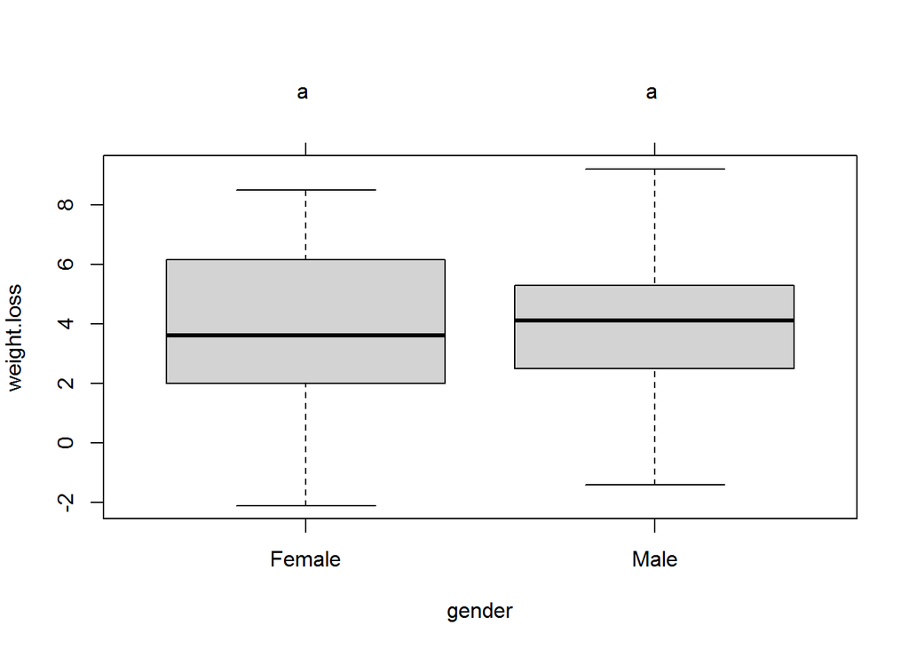

```r
#Tukey honest significant differences test)
par(mar=c(5,4,6,2))
tuk.noout <- glht(fit.noout, linfct=mcp(gender="Tukey"))
plot(cld(tuk.noout, level=.05),col="lightgrey")
```

Вывод: величина потери веса практически не зависит от пола - разница очень незначительна (Male-Female = 0.12). По графикам также видно, что средние значения, полученные для мужчин и женщин, практически одинаковы, а уровень значимости для построенной модели равен 0.835 (при этом максимальный допустимый порог равняется 0.05).

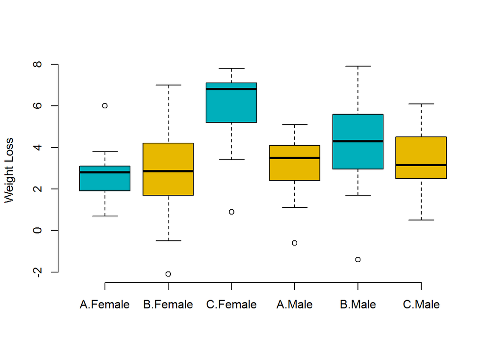

```r
#Двухфакторный дисперсионный анализ

#Определение выбросов
data.noout.3<-data.noout[!is.na(data.noout$gender),]
data.noout.3$gender <- factor(c("Female","Male")[as.ordered(data.noout.3$gender)])

#Проанализиуем различия по типу диеты и полу
boxplot(weight.loss ~ diet.type * gender, data=data.noout.3, frame = FALSE,
        col = c("#00AFBB", "#E7B800"), ylab="Weight Loss")
```

```r
library("ggpubr")
```

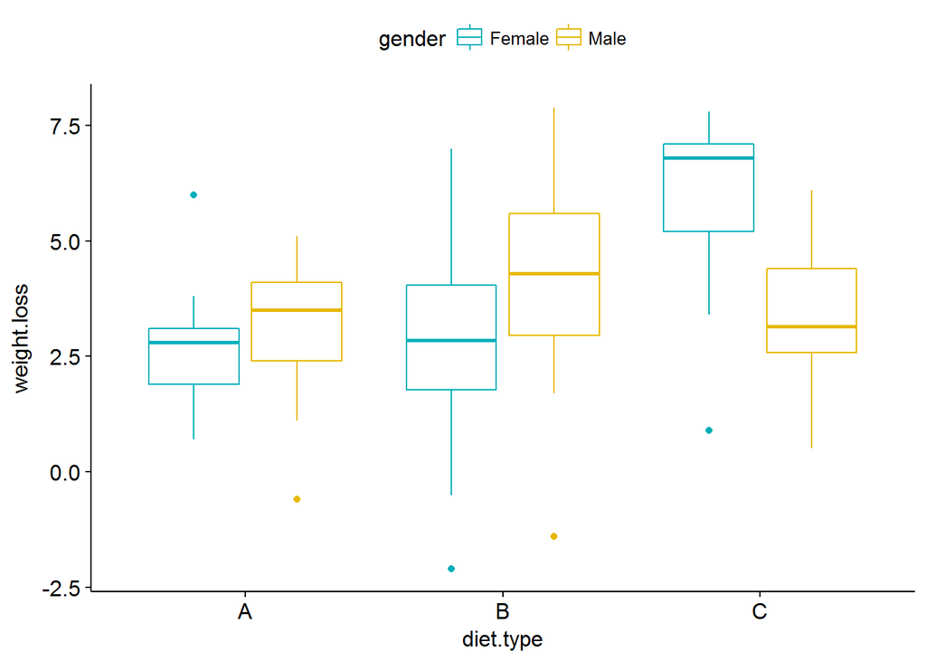

```r
ggboxplot(data.noout.3, x = "diet.type", y = "weight.loss", color = "gender",
          palette = c("#00AFBB", "#E7B800"))
```

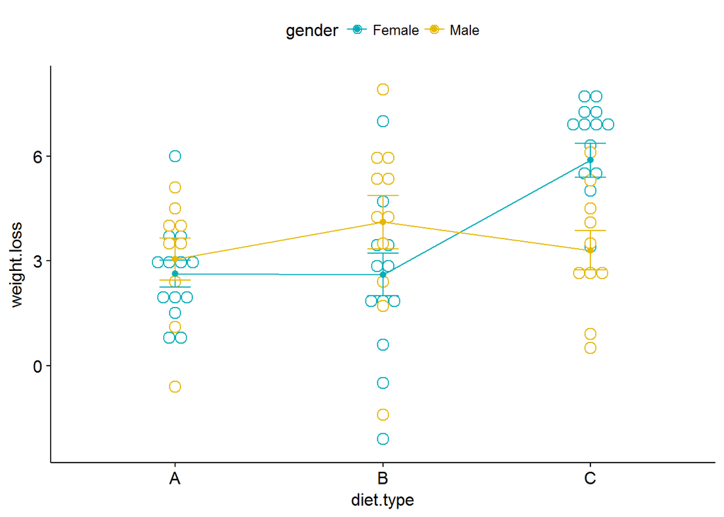

```r
#График групповых средних в зависимости от пола
ggline(data.noout.3, x = "diet.type", y = "weight.loss", color = "gender",
       add = c("mean_se", "dotplot"),
       palette = c("#00AFBB", "#E7B800"))
```

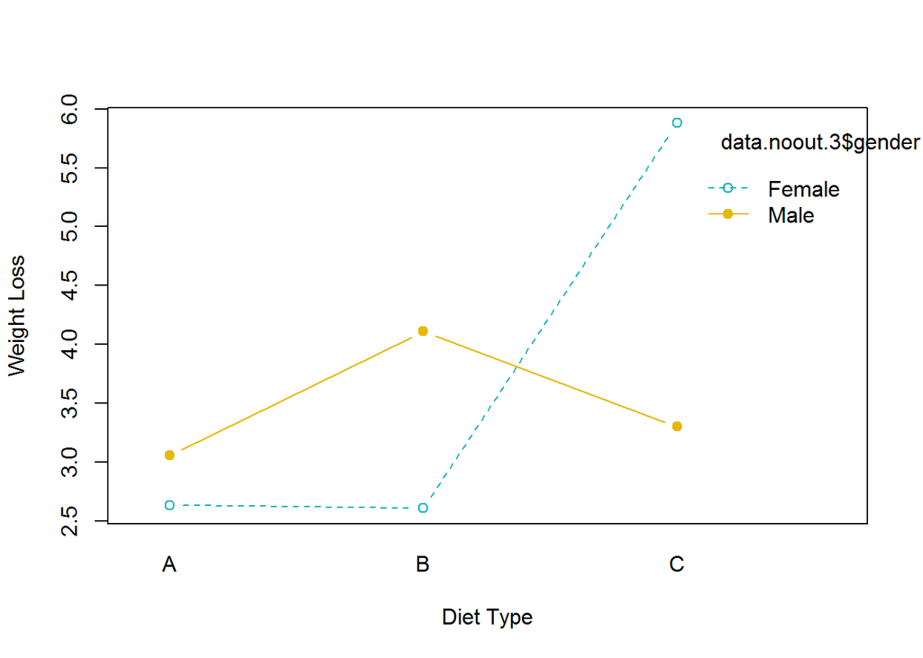

```r
#График двухфакторного взаимодействия
interaction.plot(x.factor = data.noout.3$diet.type, trace.factor = data.noout.3$gender,
                 response = data.noout.3$weight.loss, fun = mean,
                 type = "b", legend = TRUE,
                 xlab = "Diet Type", ylab="Weight Loss",
                 pch=c(1,19), col = c("#00AFBB", "#E7B800"))
```

```r
#Для подгонки ANOVA модели используем функцию aov, частный случай линейной модели lm
#тест на межгрупповые различия
fit.noout <- aov(weight.loss ~ diet.type*gender, data=data.noout.3)
summary(fit.noout)
```

```
##                  Df Sum Sq Mean Sq F value  Pr(>F)
## diet.type         2  55.21  27.604   7.005 0.00174 **
## gender            1   0.90   0.901   0.229 0.63407
## diet.type:gender  2  53.89  26.946   6.838 0.00200 **
## Residuals        66 260.09   3.941
## ---
## Signif. codes:  0 '***' 0.001 '**' 0.01 '*' 0.05 '.' 0.1 ' ' 1
```

```r
#Tukey honest significant differences test
TukeyHSD(fit.noout)
```

```
##   Tukey multiple comparisons of means
##     95% family-wise confidence level
##
## Fit: aov(formula = weight.loss ~ diet.type * gender, data = data.noout.3)
##
## $diet.type
##          diff        lwr      upr     p adj
## B-A 0.4634545 -0.9279541 1.854863 0.7051731
## C-A 2.0434545  0.6520459 3.434863 0.0022351
## C-B 1.5800000  0.2337302 2.926270 0.0174777
##
## $gender
##                   diff       lwr       upr     p adj
## Male-Female -0.2267948 -1.174244 0.7206547 0.6342823
##
## $`diet.type:gender`
##                          diff        lwr        upr     p adj
## B:Female-A:Female -0.02362637 -2.2678187  2.2205660 1.0000000
## C:Female-A:Female  3.24923077  1.0413501  5.4571115 0.0007386
## A:Male-A:Female    0.42478632 -2.1017893  2.9513619 0.9962485
## B:Male-A:Female    1.47832168 -0.9086732  3.8653166 0.4617015
## C:Male-A:Female    0.66923077 -1.7815594  3.1200210 0.9662681
## C:Female-B:Female  3.27285714  1.1076311  5.4380832 0.0004917
## A:Male-B:Female    0.44841270 -2.0409750  2.9378004 0.9948141
## B:Male-B:Female    1.50194805 -0.8456489  3.8495450 0.4247149
## C:Male-B:Female    0.69285714 -1.7195771  3.1052914 0.9582157
## A:Male-C:Female   -2.82444444 -5.2811473 -0.3677416 0.0150781
## B:Male-C:Female   -1.77090909 -4.0838183  0.5420002 0.2307413
## C:Male-C:Female   -2.58000000 -4.9586923 -0.2013077 0.0258648
## B:Male-A:Male      1.05353535 -1.5653187  3.6723894 0.8444070
## C:Male-A:Male      0.24444444 -2.4326854  2.9215743 0.9998039
## C:Male-B:Male     -0.80909091 -3.3549080  1.7367262 0.9365441
```

Вывод: несмотря на то, что сам по себе пол практически не влияет на величину потери веса, зависимости, полученные при двухфакторном анализе, показывают, что он оказывает серьезное влияние на действенность диет различных типов. Так, уровень значимости для пола по отношению к типу диеты равен 0.002, что достаточно меньше 0.05. По графикам групповых средних в зависимости от пола видно, что для женщин диета С намного лучше, чем диеты А и В (которые обе в равной степени плохи). Однако для мужчин результат вышео иным - в этом случае самой действенной диетой оказалась диета В, а А и С находятся на равном уровне. Тот же результат подтвеждают и графики boxlot, а результаты теста TukeyHSD показывают следующее: C:Female-A:Female 3.24923077, C:Female-B:Female 3.2728571, B:Male-A:Male 1.05353535, C:Male-B:Male -0.80909091. Таким образом, при исследовании женской группы разница между диетой С и двумя другими диетами оказалась еще больше, чем при исследовании всей выборки, а в мужской группе наибольшая разница оказалась между диетой В и другими, то есть в данном случае диета В работает лучше остальных.

```r
#Ковариационный анализ (ANCOVA)

fit <- aov(weight.loss ~ diet.type+height, data=data.noout)
summary(fit)
```

```
##             Df Sum Sq Mean Sq F value  Pr(>F)
## diet.type    2   61.7  30.856   6.466 0.00265 **
## height       1    0.6   0.608   0.127 0.72213
## Residuals   70  334.1   4.772
## ---
## Signif. codes:  0 '***' 0.001 '**' 0.01 '*' 0.05 '.' 0.1 ' ' 1
```

Ковариационный анализ (ANCOVA) представляет собой дисперсионный анализ, который включает в себя как категориальные независимые переменные, называемые факторами, так и метрические независимые переменные, называемые «ковариатами».

Вывод: при добавлении высоты в качестве ковариаты к модели ANOVA, анализирующей зависимость потери веса от типа диеты, можно увидеть, что для данной ковариаты уровень значимости равен 0.722, что заметно превышает допустимый порог, равный 0,05, следовательно можно сделать вывод, что в условиях применения раличных типов диет высота пациента не оказывает существенного влияния на потерю веса.